# Qiime_analy

Julia Pierce (24366429)

3/14/2018

# Abstract

# Introduction

# Methods

# Results

## Data cleaning

Data were loaded into R.

## How does microbial community structure change with depth and oxygen ceocentration?

#### Alpha-diversity

Alpha-diversity and richness were calculated for the total community in R.

```r
load("qiime2_phyloseq.RData")
```

Samples were rarefied/normalized to 100,000 sequences per sample to facilitate comparisons between samples. A random seed was set to ensure reproducibility.

```r
set.seed(4832)
m.norm = rarefy_even_depth(qiime2, sample.size=100000)
```

```
## You set `rngseed` to FALSE. Make sure you've set & recorded
##  the random seed of your session for reproducibility.
## See `?set.seed`
```

```
## ...
```

```
## 6OTUs were removed because they are no longer
## present in any sample after random subsampling
```

```
## ...
```

Rarefied counts were converted to relative abundance percentages.

```r
m.perc = transform_sample_counts(m.norm, function(x) 100 * x/sum(x))
```

```r
# Calculation
m.alpha = estimate_richness(m.norm, measures = c("Chao1", "Shannon"))
m.meta.alpha = full_join(rownames_to_column(m.alpha), rownames_to_column(data.frame(m.perc@sam_data)), by = "rowname")
m.meta.alpha
```

```
##       rowname    Chao1  se.chao1  Shannon Depth_m   O2_uM PO4_uM SiO2_uM
## 1 Saanich_010 566.0000 0.0000000 5.046089      10 216.667  0.520  20.672
## 2 Saanich_100 764.7500 1.4237029 5.140263     100  38.012  3.672  69.062
## 3 Saanich_120 798.5000 3.4452856 4.811825     120  32.354  4.090  64.383
## 4 Saanich_135 645.2500 1.7327981 4.185610     135  20.446  4.342  70.321
## 5 Saanich_150 572.0000 1.8177848 3.328242     150   0.000  4.988  70.780
## 6 Saanich_165 483.1429 0.4869678 3.164047     165   0.000  5.599  62.580
## 7 Saanich_200 514.2500 1.7327730 2.971639     200   0.000  6.298  66.200
##   NO3_uM NH4_uM Std_NH4_uM NO2_uM Std_NO2_uM  H2S_uM Std_H2S_uM Cells.ml
## 1  1.793 0.4080     0.0084 0.1275     0.0088  0.0000     0.0000      NAN
## 2 26.400 0.1344     0.0092 0.0817     0.0105  0.0000     0.0000      NAN
## 3 21.302 0.1782     0.0100 0.0978     0.0018  0.0000     0.0000      NAN
## 4 15.917 0.1296     0.0166 0.0706     0.0018  0.0000     0.0000      NAN
## 5  5.278 2.1754     0.0293 0.1127     0.0018  0.0000     0.0000      NAN
## 6  0.000 4.7095     0.2112 0.0805     0.0053  3.5027     0.0423      NAN
```

[output cut: 17 more lines]

Example plots

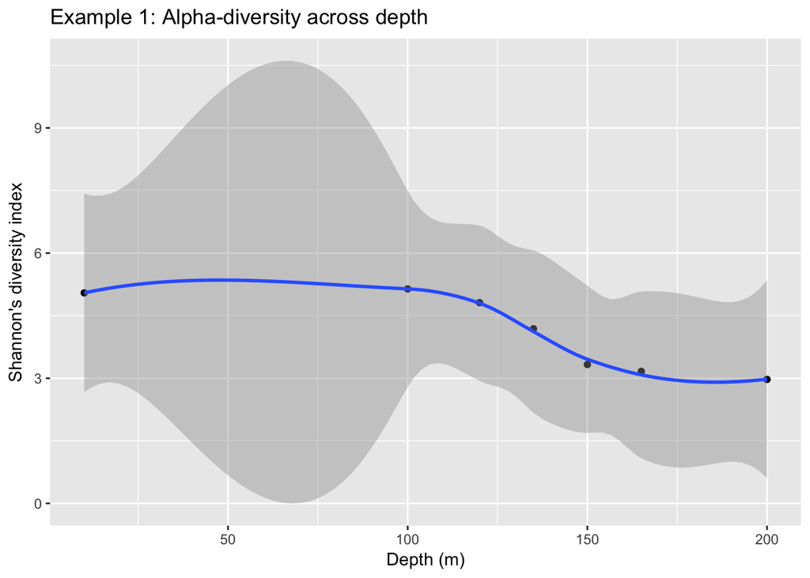

```r
m.meta.alpha %>%

ggplot() +
  geom_point(aes(x=Depth_m, y=Shannon)) +
   geom_smooth(method='auto', aes(x=as.numeric(Depth_m), y=Shannon)) +
  labs(title="Example 1: Alpha-diversity across depth", y="Shannon's diversity index", x="Depth (m)")
```

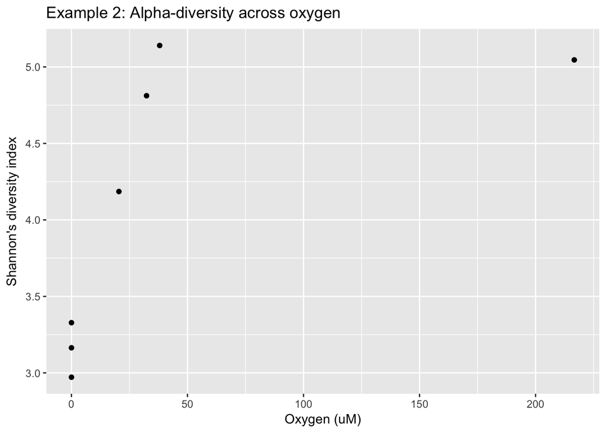

```r
m.meta.alpha %>%

ggplot() +
  geom_point(aes(x=O2_uM, y=Shannon)) +
  labs(title="Example 2: Alpha-diversity across oxygen", y="Shannon's diversity index", x="Oxygen (uM)")
```

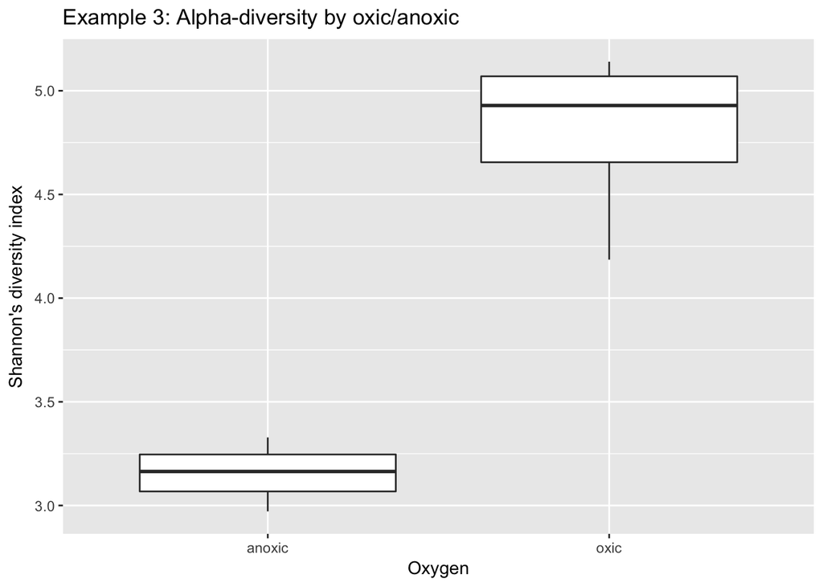

```r
m.meta.alpha %>%
  mutate(O2_group = ifelse(O2_uM == 0, "anoxic", "oxic")) %>%

# Use this in a plot
ggplot() +
  geom_boxplot(aes(x=O2_group, y=Shannon)) +
  labs(title="Example 3: Alpha-diversity by oxic/anoxic", y="Shannon's diversity index", x="Oxygen")
```

#### Taxa presence and abundance

Example plots using `phyloseq` for domain data. You should explore other taxonomy levels.

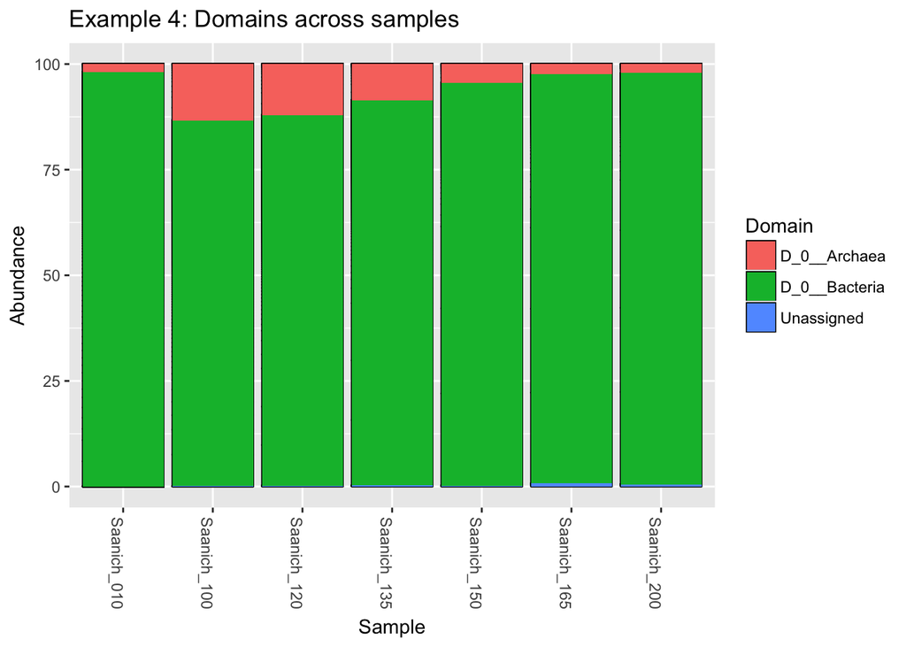

```r
m.perc %>%
plot_bar(fill="Domain") +
  geom_bar(aes(fill=Domain), stat="identity") +
  labs(title="Example 4: Domains across samples")
```

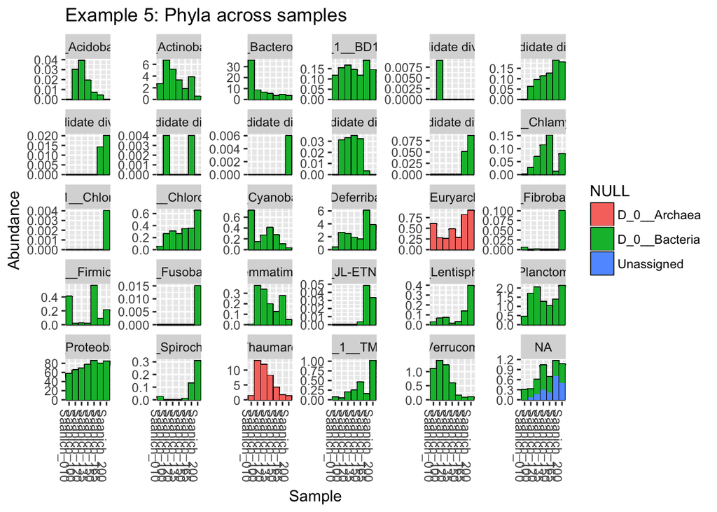

```r
m.perc %>%
plot_bar() +
  geom_bar(aes(fill=Domain), stat="identity") +
  facet_wrap(~Phylum, scales="free_y")+
  labs(title="Example 5: Phyla across samples")
```

[figure not shown]

```r
m.perc %>%
plot_bar() +
  geom_bar(aes(fill=Domain), stat="identity") +
  facet_wrap(~Genus, scales="free_y")+
  labs(title="Example 6: Genus across samples")
```

Examples outside of phyloseq

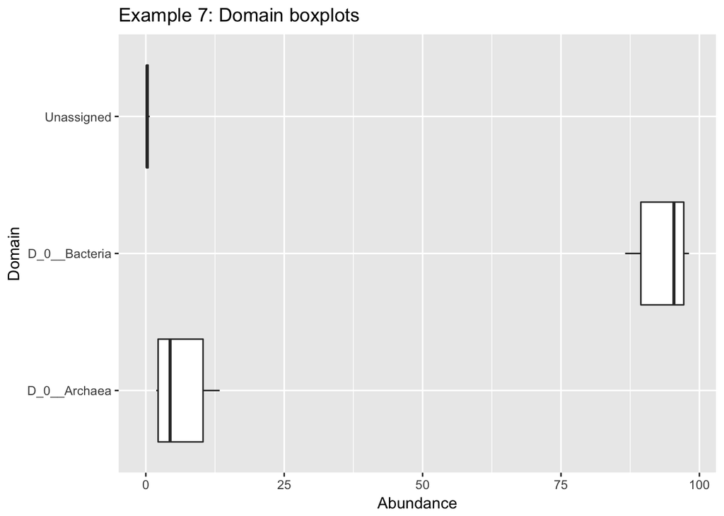

```r
m.perc %>%
  tax_glom(taxrank = 'Domain') %>%
  psmelt() %>%

ggplot() +
  geom_boxplot(aes(x=Domain, y=Abundance)) +
  coord_flip() +
  labs(title="Example 7: Domain boxplots")
```

[figure not shown]

```r
m.perc %>%
  tax_glom(taxrank = 'Genus') %>%
  psmelt() %>%

ggplot() +
  geom_boxplot(aes(x=Genus, y=Abundance)) +
  coord_flip() +
  labs(title="Example 8: Genus boxplots")
```